# Latihan-5

Lutfi Syahreza Lubis

2023-09-26

## Used Packages

```r
library(ggplot2)
library(tsibble)
library(tseries)
library(MASS)
```

## Importing data

```r
data_air <- rio::import("https://raw.githubusercontent.com/lutfi-reza/mpdw-lutfi-reza/main/data/data_air.csv")
```

## Plot Time Series

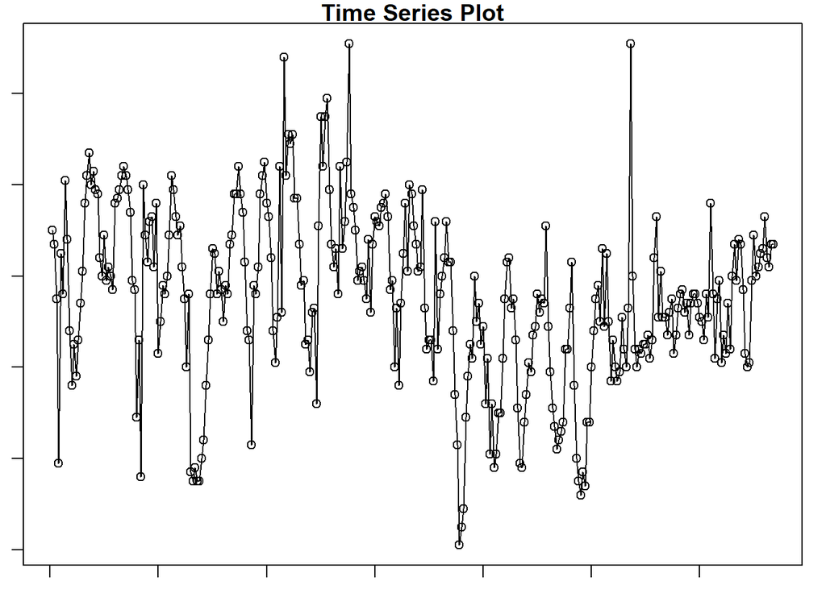

```r
data_air.ts <- ts(data_air$tinggi_air)
par(mar = c(1, 1, 1, 1))
ts.plot(data_air.ts, xlab="Time Period ", ylab="Reading",
        main = "Time Series Plot")
points(data_air.ts)
```

### Plot ACF

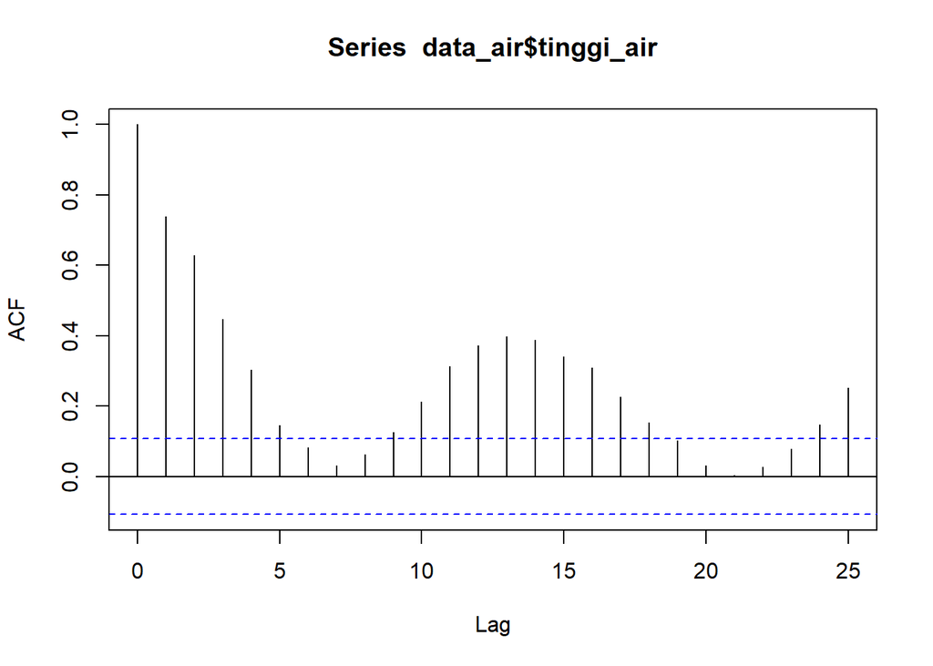

```r
acf(data_air$tinggi_air)
```

Berdasarkan plot ACF, terlihat bahwa plot ACF tinggi_air pada data tersebut cenderung *tails off* dan membentuk gelombang sinus.

### Uji ADF

```r
tseries::adf.test(data_air$tinggi_air)
```

```
##
##  Augmented Dickey-Fuller Test
##
## data:  data_air$tinggi_air
## Dickey-Fuller = -5.5467, Lag order = 6, p-value = 0.01
## alternative hypothesis: stationary
```

$H_0$ : Data tidak stasioner dalam rataan

$H_1$ : Data stasioner dalam rataan

Berdasarkan uji ADF tersebut, didapat *p-value* sebesar 0.01 yang lebih kecil dari taraf nyata 5% sehingga tolak $H_0$ dan menandakan bahwa data stasioner dalam rataan. Hal ini sesuai dengan hasil eksplorasi menggunakan plot time series dan plot ACF.

### Plot Box-Cox

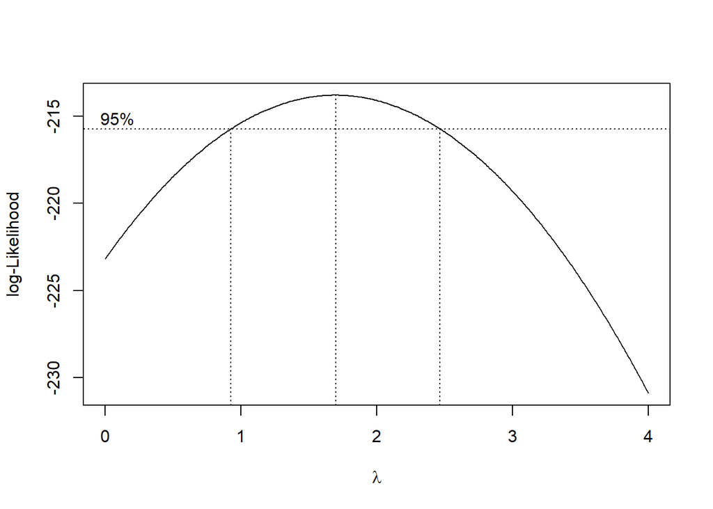

```r
index <- seq(1:334) ## 200 jumlah data
bc = boxcox(data_air$tinggi_air~index, lambda = seq(0,4,by=0.01)) #stas data kita
```

```r
#Nilai Rounded Lambda
lambda1 <- bc$x[which.max(bc$y)]
lambda1
```

```
## [1] 1.7
```

```r
#SK
bc$x[bc$y > max(bc$y) - 1/2 * qchisq(.95,1)] #rumus box coxnya
```

```
##   [1] 0.93 0.94 0.95 0.96 0.97 0.98 0.99 1.00 1.01 1.02 1.03 1.04 1.05 1.06 1.07
##  [16] 1.08 1.09 1.10 1.11 1.12 1.13 1.14 1.15 1.16 1.17 1.18 1.19 1.20 1.21 1.22
##  [31] 1.23 1.24 1.25 1.26 1.27 1.28 1.29 1.30 1.31 1.32 1.33 1.34 1.35 1.36 1.37
##  [46] 1.38 1.39 1.40 1.41 1.42 1.43 1.44 1.45 1.46 1.47 1.48 1.49 1.50 1.51 1.52
##  [61] 1.53 1.54 1.55 1.56 1.57 1.58 1.59 1.60 1.61 1.62 1.63 1.64 1.65 1.66 1.67
##  [76] 1.68 1.69 1.70 1.71 1.72 1.73 1.74 1.75 1.76 1.77 1.78 1.79 1.80 1.81 1.82
##  [91] 1.83 1.84 1.85 1.86 1.87 1.88 1.89 1.90 1.91 1.92 1.93 1.94 1.95 1.96 1.97
## [106] 1.98 1.99 2.00 2.01 2.02 2.03 2.04 2.05 2.06 2.07 2.08 2.09 2.10 2.11 2.12
## [121] 2.13 2.14 2.15 2.16 2.17 2.18 2.19 2.20 2.21 2.22 2.23 2.24 2.25 2.26 2.27
## [136] 2.28 2.29 2.30 2.31 2.32 2.33 2.34 2.35 2.36 2.37 2.38 2.39 2.40 2.41 2.42
## [151] 2.43 2.44 2.45 2.46
```

### Partisi Data

#### Bagian 1

```r
dt_air1 <- data_air$tinggi_air[1:175] |> ts()
mean(dt_air1)
```

```
## [1] 1830.629
```

```r
var(dt_air1)
```

```
## [1] 33145
```

## Plot Time Series Data Partisi Bagian 1

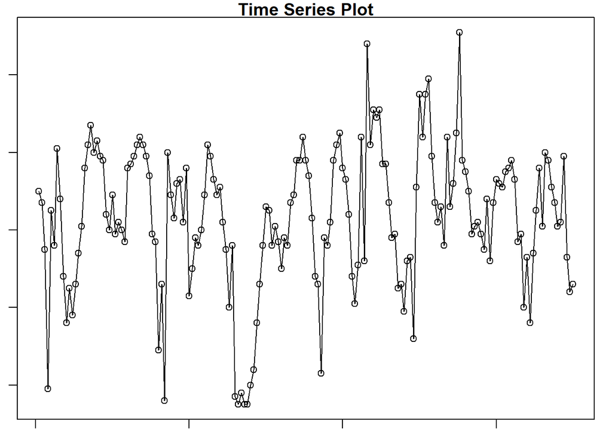

```r
dt_air1.ts <- ts(dt_air1)
par(mar = c(1, 1, 1, 1))
ts.plot(dt_air1.ts, xlab="Time Period ", ylab="Reading",
        main = "Time Series Plot")
points(dt_air1.ts)
```

#### Plot ACF

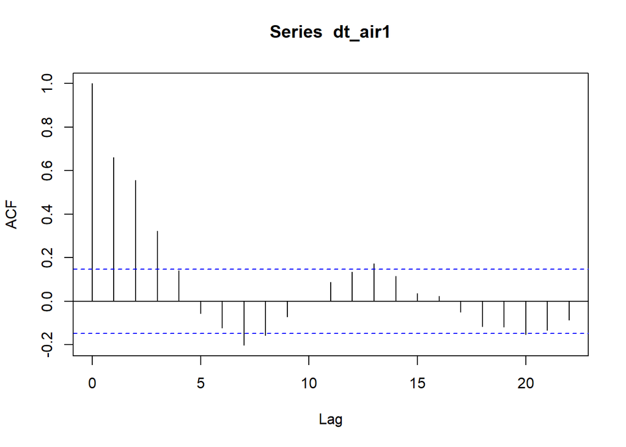

```r
acf(dt_air1)
```

Berdasarkan plot ACF, terlihat bahwa plot ACF pada data tersebut cenderung *tails off* dan membentuk gelombang sinus.

#### Uji ADF

```r
tseries::adf.test(dt_air1)
```

```
##
##  Augmented Dickey-Fuller Test
##
## data:  dt_air1
## Dickey-Fuller = -5.0128, Lag order = 5, p-value = 0.01
## alternative hypothesis: stationary
```

$H_0$ : Data tidak stasioner dalam rataan

$H_1$ : Data stasioner dalam rataan

Berdasarkan uji ADF tersebut, didapat *p-value* sebesar 0.01 yang lebih kecil dari taraf nyata 5% sehingga tolak $H_0$ dan menandakan bahwa data stasioner dalam rataan. Hal ini sesuai dengan hasil eksplorasi menggunakan plot time series dan plot ACF.

#### Plot Boxcox

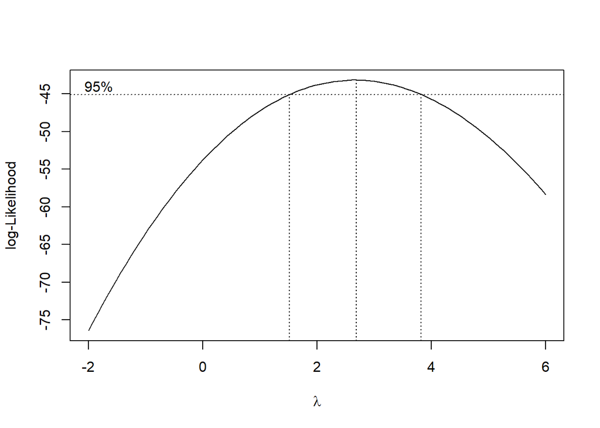

```r
index <- seq(1:175)
bc = boxcox(dt_air1~index, lambda = seq(-2,6,by=1))
```

```r
#Nilai Rounded Lambda
lambda <- bc$x[which.max(bc$y)]
lambda
```

```
## [1] 2.686869
```

```r
#SK
bc$x[bc$y > max(bc$y) - 1/2 * qchisq(.95,1)]
```

```
##  [1] 1.555556 1.636364 1.717172 1.797980 1.878788 1.959596 2.040404 2.121212
##  [9] 2.202020 2.282828 2.363636 2.444444 2.525253 2.606061 2.686869 2.767677
## [17] 2.848485 2.929293 3.010101 3.090909 3.171717 3.252525 3.333333 3.414141
## [25] 3.494949 3.575758 3.656566 3.737374 3.818182
```

Gambar di atas menunjukkan nilai *rounded value* ($\lambda$) optimum sebesar **2.686869** dan pada selang kepercayaan 95% nilai memiliki batas bawah **1.555556** dan batas atas **3.818182**. Selang tersebut tidak memuat nilai satu sehingga dapat dikatakan bahwa data tidak stasioner dalam ragam.

#### Bagian 2

```r
dt_air2 <- data_air$tinggi_air[1:250] |> ts()
mean(dt_air2)
```

```
## [1] 1760.12
```

```r
var(dt_air2)
```

```
## [1] 43297.58
```

## Plot Time Series Data Partisi Bagian 2

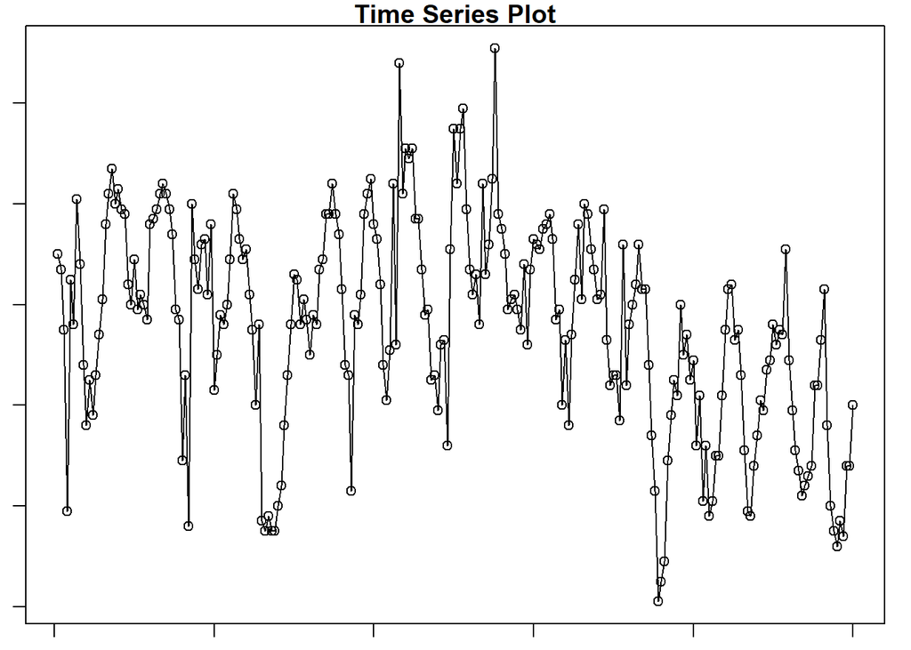

```r
dt_air2.ts <- ts(dt_air2)
par(mar = c(1, 1, 1, 1))
ts.plot(dt_air2.ts, xlab="Time Period ", ylab="Reading",
        main = "Time Series Plot")
points(dt_air2.ts)
```

#### Plot ACF

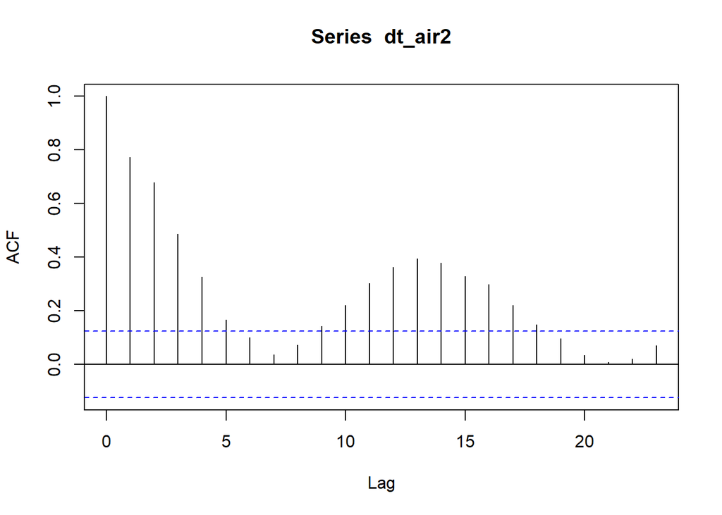

```r
acf(dt_air2)
```

Berdasarkan plot ACF, terlihat bahwa plot ACF pada data tersebut cenderung *tails off* dan membentuk gelombang sinus.

#### Uji ADF

```r
tseries::adf.test(dt_air2)
```

```
##
##  Augmented Dickey-Fuller Test
##
## data:  dt_air2
## Dickey-Fuller = -4.8348, Lag order = 6, p-value = 0.01
## alternative hypothesis: stationary
```

$H_0$ : Data tidak stasioner dalam rataan

$H_1$ : Data stasioner dalam rataan

Berdasarkan uji ADF tersebut, didapat *p-value* sebesar 0.01 yang lebih kecil dari taraf nyata 5% sehingga tolak $H_0$ dan menandakan bahwa data stasioner dalam rataan. Hal ini sesuai dengan hasil eksplorasi menggunakan plot time series dan plot ACF.

#### Plot Boxcox

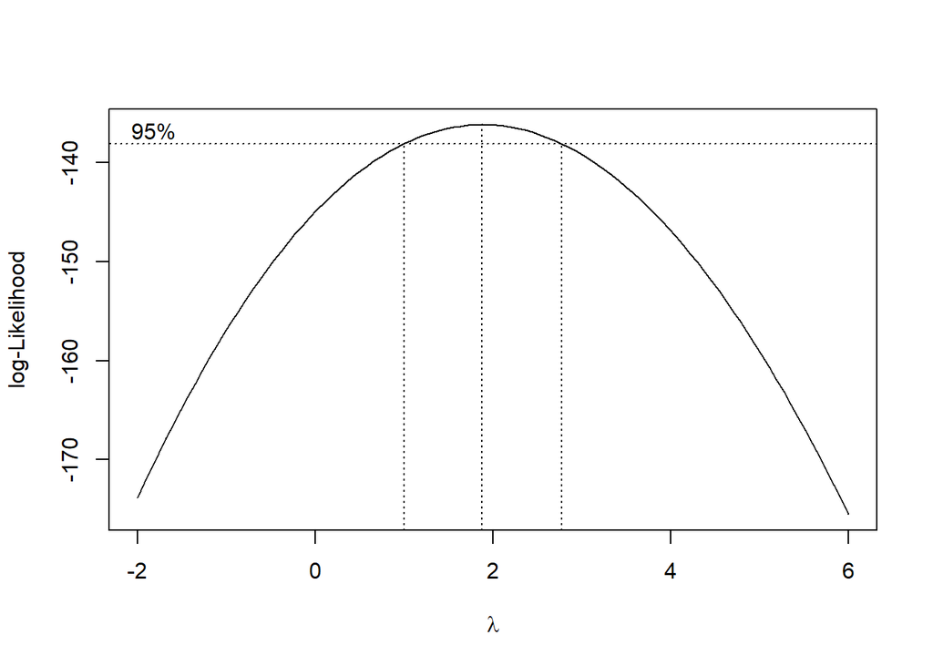

```r
index <- seq(1:250)
bc = boxcox(dt_air2~index, lambda = seq(-2,6,by=1))
```

```r
#Nilai Rounded Lambda
lambda2 <- bc$x[which.max(bc$y)]
lambda2
```

```
## [1] 1.878788
```

```r
#SK
bc$x[bc$y > max(bc$y) - 1/2 * qchisq(.95,1)]
```

```
##  [1] 1.070707 1.151515 1.232323 1.313131 1.393939 1.474747 1.555556 1.636364
##  [9] 1.717172 1.797980 1.878788 1.959596 2.040404 2.121212 2.202020 2.282828
## [17] 2.363636 2.444444 2.525253 2.606061 2.686869 2.767677
```

Gambar di atas menunjukkan nilai *rounded value* ($\lambda$) optimum sebesar **1.878788** dan pada selang kepercayaan 95% nilai memiliki batas bawah **1.070707** dan batas atas **2.767677**. Selang tersebut tidak memuat nilai satu sehingga dapat dikatakan bahwa data tidak stasioner dalam ragam.